Tholonia - 014-APPLICATIONS  
The Existential Mechanics of Awareness  
Duncan Stroud  
Published: January 15, 2020  
Updated: Updated: Mar 26, 2026 v8.0.89  
Welkin Wall Publishing  
ISBN-10:  
ISBN-13: 978-1-6780-2532-8  
Copyright ©2020 Duncan Stroud CC BY-NC-SA 4.0

This book is an open sourced book. This means that anyone can contribute changes or updates. Instructions and more information at https://tholonia.github.io/the-book (or contact the author at duncan.stroud@gmail.com). This book and its on-line version are distributed under the terms of the Creative Commons Attribution-Noncommercial-ShareAlike 4.0 International (CC BY-NC-SA 4.0) license, with the additional proviso that the right to publish it on paper for sale or other for-profit use is reserved to Duncan Stroud and authorized agents thereof. A reference copy of this license may be found at https://creativecommons.org/licenses/by-nc-sa/4.0/. The above terms include the following: Attribution - you must give appropriate credit, provide a link to the license, and indicate if changes were made. You may do so in any reasonable manner, but not in any way that suggests the licensor endorses you or your use. Noncommercial - You may not use the material for commercial purposes. Share Alike - If you remix, transform, or build upon the material, you must distribute your contributions under the same license as the original. No additional restrictions - you may not apply legal terms or technological measures that legally restrict others from doing anything the license permits. Notices - You do not have to comply with the license for elements of the material in the public domain or where your use is permitted by an applicable exception or limitation. No warranties are given. The license may not give you all of the permissions necessary for your intended use. For example, other rights such as publicity, privacy, or moral rights may limit how you use the material.

# 14: APPLICATIONS

###### Tholonic patterns applied: from mathematical laws to the shape of all knowledge

##### **Synopsis:** Having identified tholonic patterns in physics and mathematics, this chapter applies those patterns outward to reveal what they mean in practice. The tetrahedron is shown to unify radically different value systems — integers, imaginary numbers, *e*, and *π* — through its structural roles. Newton’s 2nd law is mapped directly onto the tholon, then extended via Ohm’s law to describe social systems: ethics, laws, and societal strength are shown to follow the same archetypal formula as voltage, resistance, and current. The mathematical meaning of operations (multiplication, division, squares) is reexamined in the tholonic context. The chapter concludes by showing that every piece of knowledge forms a tetrahedron, and DNA’s tetrahedral structure hints at deep tholonic roots underlying biology and information itself.

##### **Keywords:** tetrahedron, Newton’s 2nd law, Ohm’s law, society, ethics, laws, sustainability, imaginary numbers, meaning of math, DNA, tetrahedral DNA, shape of knowledge, N-D-C

## The Bigger Picture

Chapter 13 demonstrated that the same N-D-C architecture appears at every scale of physical reality, from quark charge distributions to molecular geometry to the growth constant *e*. The question this chapter addresses is what those patterns mean in practice, when applied outward from physics and mathematics to social systems, cognition, and biology.

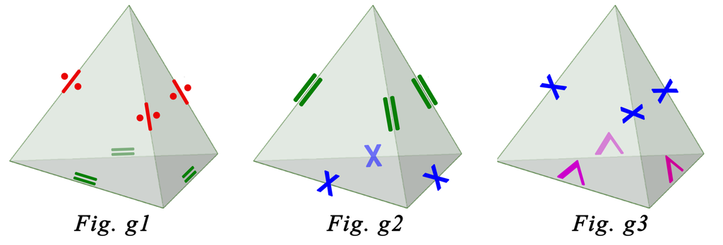

It may look like our math has taken some “liberties” using more exotic values to support the argument that there is a natural and fundamental pattern of order that can be seen in the tetrahedron, and there are probably a lot of patterns that can be applied with various numbers that make the same “sense”. That would be partly true, as the tetrahedron contains all kinds of patterns that can be seen in nature and math, but some are more “in your face” than others.

For example, when we use the numbers 6, 2, and 3 for our trigram corner points, we can see a pattern of division (*Fig. g1*) and a pattern of multiplication (*Fig. g2*). It is worth remembering that the pattern of 2 × 3 = 6 is the most fundamental pattern of relationships that all interactions of matter are based on, as previously demonstrated. These are the same patterns for **+** and **-** as well. When we use *e*, *i*, and *π*, we can see a pattern of multiplication and exponents (*Fig. g3*).

Each of these patterns represents different ways energy moves in a tholon and requires different types of values to function properly. The values of 6, 2, and 3 work with patterns **g1** and **g2**, but not in the same manner with pattern **g3**, which works with values *e*, *i*, and *π*, but they support each other.

For example, if we only use values of *i* for pattern **g1**, using the values of *i<sup>1</sup>*, *i<sup>2</sup>*, *i<sup>3</sup>*, we get values of *i*, *-1*, *-i*, which perfectly comply with pattern **g1** as i/(-1) = -i, i/(-i) = -1, and i × -1 = -i. But this is a tetrahedron, so we need that 4<sup>th</sup> *white dot* point that needs to be a value that is fundamental to, and compatible with, all the other values. That would be *i<sup>0</sup>*, which is 1 and the value that all these values are derived from. And with that, all the formulas work.

If we continued with *i<sup>5</sup>*, *i<sup>6</sup>*, and so on, we would get the same values because no matter how many multiples of i are used, it can only result in *1*, *i*, *-1*, or *-i*, which is yet more validation of the tetrahedron model. This pattern also tells us that the cardinal values of the points on a trigram are the exponential values of 1 (at the top), then 2 and 3, with the 4<sup>th</sup> point as 0 *after* the tholonic trigram has created its 3 children and folded into a tetrahedron. So, while the instances of the pattern are different, the pattern shows how different types of functions are grouped by the base and side trigrams.

## Back to Basics

Let’s now map Newton’s 2<sup>nd</sup> law (in the form of Ohm’s law) to the tholon, which fits nicely.

To apply Ohm’s law, we have to correlate the N, D, and C values to V, I, and R, like so:

- **N** (negotiation) as V (voltage, potential, and field of potential)
- **D** (definition) with R (resistance, opposition to free flow)
- **C** (contribution) with I (current, force of flow)

This allows us to state the following:

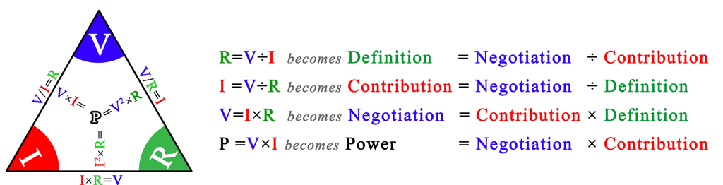

We’ve taken a big leap here by applying math to such abstract concepts and expecting to see something meaningful, but if we look at these definitions as abstractions, they seem quite reasonable, just as they did to the founders of mathematics.

## The (lost) Meaning of Math

To look closer, we need to make sure we’re all on the same page regarding how the trigram can describe the math functions of Ohm’s law, and to do that, we need to clarify some elementary concepts, such as what the math symbols mean in this context.

Addition and subtraction are easy concepts to grasp. We take some number of things and add or remove some number of things. But depending on the context, even simple addition and subtraction require some extra thought. A good example of this is how addition and subtraction affect colors. It is not intuitive to most people that *violet - cyan = blue*, for example, but once shown, it makes sense.

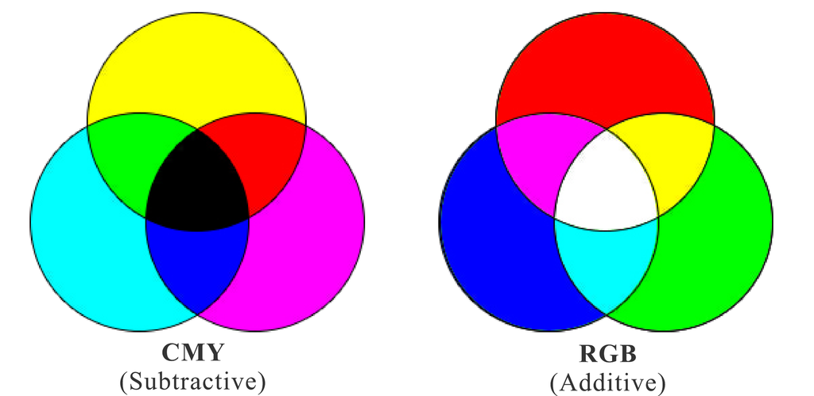

What about multiplication and division? In this context, we will describe division as *the definition of one value by the units of another value*.

For example, in division, such as 3 = 12/4, we are stating that 3 is what we get when we measure an existing value of 12 by a unit of 4. In multiplication, such as 12 = 3 × 4, we are determining a new value of 12 by combining 3 of these units-of-4.

The 4, as the divisor or multiplier, is the *unit of measurement*, and the 3 is the *number of units*. Every kid knows what was just stated, but when we apply those same simple rules and concepts to a non-math context, they become very significant.

As mentioned above, we would expect to see the same laws expressed in different ways across all the scopes that the laws apply to, so we would expect to see an example of Newton’s 2<sup>nd</sup> law in the tholonic realms of society, or planets, or organisms, and we do. For comparison, we also show how the attributes of the tholon would appear using the same laws.

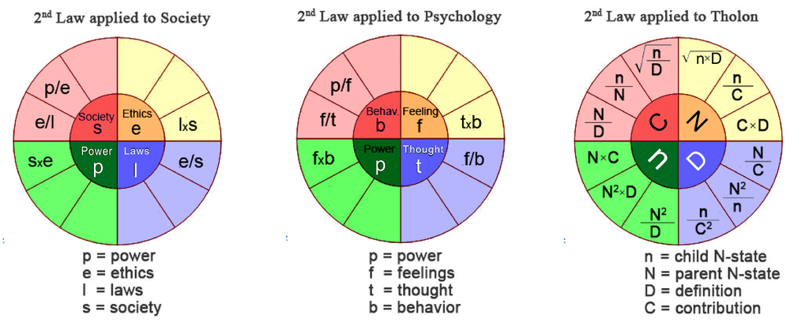

For example, if we claim that a **society** is based on its **ethics** and we also posit that **ethics** are to be measured by **laws**, we can say *society = ethics ÷ laws*, and likewise, *ethics = laws × society*. Suppose we measure the **power** of a **society** by its ability to function or “**work**”, and the measure of a **society** by its **sustainability**, then, according to these formulas. In that case, a **society** with a lot of **laws** and very little **ethics** will **work** less and be less **sustainable**. On the other hand, a **society** that has a lot of **ethics** and very few **laws** will be far more **sustainable** and produce even more **work**.

Here, we interpret “laws” as *limiting factors* with regard to its members. Those limits could even be limits on limits, e.g., The 1<sup>st</sup> amendment of the U.S. Constitution, guaranteeing the right to free speech is a law, but it is a limitation on a limitation in that it limits the State from limiting an individual’s right. For context, an example of a society with a lot of limiting laws and very little ethics would be North Korea or Syria. An example of a society with fewer limiting laws and higher ethics would be Norway or Sweden. *Note: These rankings are according to institutions that rank countries [^1]and not necessarily the examples I would personally choose*.

If we claim that individuals interacting with each other (commerce, culture, aid, community) represents the strength of a society, and we use the concept of **society** to represent this strength of social interaction, then we might say this interaction correlates with *current*. If *ethics* represents the arena in which individuals operate, then we could correlate *ethics* with *voltage*. *Laws*, which define limits, would then reasonably be correlated to *resistance*. Altogether, individuals, ethics, and laws form a *society*.

We are effectively assigning the values of:

- 3 = *society* (strength of interaction) and equates to **current** (I) or **acceleration** (a)
- 6 = *ethics* and equates to **voltage** (V) or **force** (F)
- 2 = *laws* and equates to **resistance** (R) of **mass** (m)
- 18 = *work* and equates to **power** (P)

These are numbers that work with Newton’s and Ohm’s law, but in this context, the quantitative value of these numbers is not important. We are using the numbers to show relationships. The number itself is merely a concept of measure. Power, which is the transference of energy over time, would then correlate to how much “work” this society could generate. Perhaps this would be seen in their social achievement, productivity, or levels of cooperation, but it could also represent a “work product” of oppression, taxation, or enslavement if that is the goal of the society.

How these assignments were arrived at is not critical because they may differ depending on how one chooses to correlate, so this detail does not matter for the point being made.

With these assignments, *society* = ethics/laws follows the same reasoning as the formula 3 = 6/2. To demonstrate how these relationships work, let us examine three different hypothetical scenarios that show what happens when we change the values of ethics and laws:

**Case 1 (Baseline scenario):** - Ethics = 6, Laws = 2 - Society = ethics/laws = 6/2 = 3 - Work = ethics × society = 6 × 3 = 18

**Case 2 (Doubled ethics, same laws):** - Ethics = 12 (doubled), Laws = 2 (unchanged) - Society = ethics/laws = 12/2 = 6 (society doubles) - Work = ethics × society = 12 × 6 = 72 (work quadruples!)

**Case 3 (Same ethics, doubled laws):** - Ethics = 6 (unchanged), Laws = 4 (doubled) - Society = ethics/laws = 6/4 = 1.5 (society reduced by half) - Work = ethics × society = 6 × 1.5 = 9 (work cut in half)

**Ranking by work efficiency:**

When we analyze these three scenarios for work efficiency (work produced per unit of total input), we can rank them as follows:

1. **Most efficient: Case 2** - Work efficiency = 72/(12+2) = 72/14 = **5.14**  
   Doubled ethics with the same laws produces the highest efficiency, with work quadrupling while total input less than doubles.
2. **Moderately efficient: Case 1** - Work efficiency = 18/(6+2) = 18/8 = **2.25**  
   The baseline scenario shows reasonable efficiency with balanced ethics and laws.
3. **Least efficient: Case 3** - Work efficiency = 9/(6+4) = 9/10 = **0.9**  
   Doubling laws while keeping ethics constant cuts work in half and results in the poorest efficiency, producing less than one unit of work per unit of input.

If this premise has any validity, this would suggest that a lot of laws and little ethics, or perhaps where the ethics are enforced by law rather than conscience, leads to an inefficient society. In contrast, a society with few laws and lots of ethics leads to a productive society.

How would we calculate *sustainability* then? Here is one way, perhaps, but this is totally outside the context of the law as we currently use it, so it will probably make no sense from an engineering perspective. In short, we simply take the product of all the unit-counts of *society* and measure it by the product of the unit-measures of *society*:

society = I = V/R or P/V or √(P/R) ∴ unit count/unit measure ∴ (V × P × √P)/(R × V × √R)

Applied to these 3 cases, we get the following sustainability calculations:

**Case 1 (Baseline):** - Formula: 6/2 or 18/6 or √(18/2) - Calculation: (6 × 18 × √18)/(2 × 6 × √2) = 458.2/16.9 - **Sustainability = 27.1**

**Case 2 (Doubled ethics):** - Formula: 12/2 or 72/12 or √(72/2) - Calculation: (12 × 72 × √72)/(2 × 12 × √2) = 7331.3/33.9 - **Sustainability = 216.3** (8× more sustainable than baseline!)

**Case 3 (Doubled laws):** - Formula: 6/4 or 9/6 or √(9/4) - Calculation: (6 × 9 × √9)/(4 × 6 × √4) = 162/48 - **Sustainability = 3.4** (8× less sustainable than baseline)

How these translate to the real world is only speculative, as it is up to the reader to decide if *laws*, *society*, *ethics*, and *work* are the best concepts to use here. If so, how are the social equivalents of *power*, *ethics*, *laws*, *work*, and *sustainability* measured, and what is the significance of squares and square-roots?

How would this look if we used concepts such as *natural rights*, *privileges* and *responsibilities*?

I suspect it would take quite a bit of discussion and research to find the best values. The point of this is to suggest that these equations would produce meaningful results with the correct values. However, someone who acts out of emotions with very little thought is bound to have a less sustainable lifestyle than one who tempers their emotions with thought, so these mappings may not be too far off.

In any case, the twelve formulas of Newton’s 2<sup>nd</sup> law show some potential when applied to other contexts and may offer a new perspective on the dynamics of culture and society that, if nothing else, raises some worthwhile questions. As it applies here, it shows how the tholon can describe everything from atoms to culture as long as we know what data to apply. Because the math involved in a tholon can be more than the reader might be interested in, more of this subject is covered in *Appendix C1, “Tholonic Math”.*

Because our 4D (3D+time) reality maps neatly into the 4D tetrahedron, especially when using the synergetic 4D quadray coordinate system based on the tetrahedron, we may be able to correlate radically different contexts, such as space-time, psychology, and electricity, to name a few.

With this in mind, let’s reexamine the previous claims that began this thread:

**Definition = Negotiation ÷ Contribution**

The definition of something is its boundaries, limits, abilities, attributes, properties, and resources. These details are the results of the scope and context of that thing’s instance. It could be environmental factors, genetic attributes, or physical limitations, such as the size and weight of a thing, energy levels, etc.

It is the nature of energy to expand (i.e., disperse due to entropy) in every way possible. That expansion is the contribution, but the resistance from these factors determines what expansions get the opportunity to be expressed and what expansions are thwarted. That battle between the force of expansion and the force of resistance is the negotiation (*see Negotiation = Contribution × Definition*).

As *Definition* is *Negotiation ÷ Contribution*, we can say that *Definition* is measured by that which is *Contributed*, or the *Definition* of something is determined by what it can (sustainably) *Contribute*.

**Contribution = Negotiation ÷ Definition**

What a thing can *Contribute* is measured by its *Definition*, but the degree to which it can contribute is determined by its environment and how it interacts with that environment. That interaction is a result of *Negotiation*. A thing must provide something that something in its environment needs; otherwise, what it has to contribute is useless and unintegratable.

**Negotiation = Contribution × Definition**

A thing’s ability to find a stable and sustainable position within its environment and scope is determined by the degree to which it can contribute with its current resources. A thing may have a *Definition* that gives it a lot of A and a little of B, but if its environment needs a lot of B and very little A, then it is B that the thing must *Contribute* to ensure its existence in that environment, or it needs to find another environment, or change its environment so that A is in more demand.

Applying different values and concepts can result in new data. We experiment with this a little, but given it is outside the central theme of this book, we have put that section under “New data?” in *Appendix C1, “Tholonic Math”*

## The shape of knowledge

The point of all this is to show one way that the tholon can be used and viewed. There are many new ways of looking at energy in all its forms when viewed tholonically.

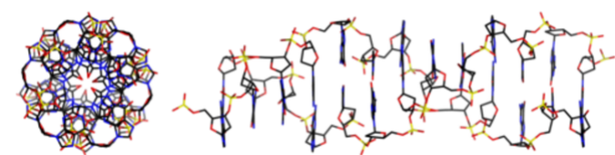

We showed examples of quarks and molecules, but in higher orders, such as DNA, we also see some striking similarities that, with a bit of investigation, would likely expose some significant relationships.

DNA and how it is both tholonic and binary in nature is examined in the companion book “*The Tholonic I-Ching*”.

DNA’s relationship with tetrahedra is particularly unique, given the creation of tetrahedrally structured DNA (a.k.a. TDN). TDN is the cutting edge of DNA nanotechnology and has various applications such as drug delivery, inhibiting certain gene expressions, and interfacing with biosensors. These TDNs assemble themselves from scratch and offer greater strength and stability than traditional dual-strand DNA. Given that there is little accessible information on TDNs for the layperson, there is not much more that can be said here other than they represent a significant advancement and will most likely play a role in future biotechnology, including potential applications in TDN-interfacing AI and DNA-integrated quantum computers.

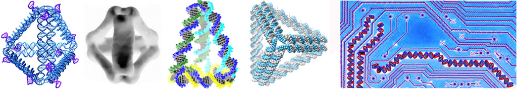

Our simple trigrams of relationships, such as Newton’s 2<sup>nd</sup> law, form conceptual *tetrahedrons* or *tholons* of relationships. Whereas before, it was stated that every piece of knowledge could be deconstructed into a trigram, by the same token, every piece of knowledge forms a tetrahedron. From social ethics to DNA nanotechnology, the same structural template holds: three functional roles, one emergent fourth point, and a pattern that scales without distortion from the subatomic to the civilisational.

What this chapter has established is that the N-D-C pattern is not a feature of carefully chosen examples but a universal constraint. Any system that must balance a generative source, a limiting definition, and an integrative contribution in order to sustain itself will exhibit this pattern, regardless of whether that system is a circuit, a society, a molecule, or a mind. The details differ; the architecture does not.

Chapter 15 takes the most intimate version of that architecture, its expression in human consciousness, and asks what it means that the organ through which we perceive and reason is itself a tholon following the same rules as everything else it perceives and reasons about.

[^1]: “**Freedom in the World**” (2018), published by Freedom House, **Democracy Index** (2017), published by The Economist Intelligence Unit, **V-Dem Annual Democracy Report** (2018), published by the V-Dem Institute